# ggplot2 example sheet

`{ggplot2}` examples

Zak Varty

2020-07-11

# Set up

The following packages will be used in this example sheet:

- `ggplot2`
- `ggthemes`
- `tidyverse`
- `extrafont`
- `patchwork`
- `cowplot`
- `grid`
- `gridExtra`
- `ggrepel`
- `reshape2`
- `ggforce`
- `ggridges`
- `shiny`

```r
required_packages <-c(
    'ggplot2',
    'ggthemes',
    'tidyverse',
    'extrafont',
    'cowplot',
    'grid',
    'gridExtra',
    'ggrepel',
    'reshape2',
    'ggforce',
    'ggridges',
    'shiny',
    'gapminder'
  )
# uncomment to install
# install.packages(required_packages)
```

# Load data

```r
gap <- gapminder::gapminder
dplyr::glimpse(gap)
```

```
## Rows: 1,704
## Columns: 6
## $ country   <fct> Afghanistan, Afghanistan, Afghanistan, Afghanistan, Afghani…
## $ continent <fct> Asia, Asia, Asia, Asia, Asia, Asia, Asia, Asia, Asia, Asia,…
## $ year      <int> 1952, 1957, 1962, 1967, 1972, 1977, 1982, 1987, 1992, 1997,…
## $ lifeExp   <dbl> 28.801, 30.332, 31.997, 34.020, 36.088, 38.438, 39.854, 40.…
## $ pop       <int> 8425333, 9240934, 10267083, 11537966, 13079460, 14880372, 1…
## $ gdpPercap <dbl> 779.4453, 820.8530, 853.1007, 836.1971, 739.9811, 786.1134,…
```

# The grammar of graphics

The “gg” in `ggplot()` and `{ggplot2}` stands for grammar of graphics. This is a philosophy of graphics generation that builds plots while treating the following components separately:

1. **Data:** the raw information that is being used to construct the plot.
2. **Statistical summaries** `stat_`: Statistical summaries of the the data, this can be a simple sum, a vector of quantiles, a fitted curve or model.
3. **Geometries** `geom_`: the geometric shapes used to represent the data or summaries on the plotting canvas.
4. **Aesthetics** `aes()`: Visual properties of the geometric and statistical objects such as size, shape, color or transparency.
5. **Scales** `scale_`: maps from data to aesthetic dimensions. For example, using the range of the data to set plot width or factor values to set point colours.
6. **Coordinate system** `coord_`: How data coordinates should be mapped onto the (rectangular) plotting canvas.
7. **Facets** `facet_`: How the data should be partitioned before creating a plot for each subset. The plotting equivalent of `dplyr::group_by()`.
8. **Visual themes** `theme()`: The default aesthetics of the plot, such as the background, grid size, axes, fonts, sizes and colors.

# The default ggplot

The `{ggplot2}` package uses a very different syntax to that used to create graphics in base R. In `{ggplot2}` plots are objects which exist in your environment and plot is created when the object is called. This isn’t strange or unusual if you think of the graphics device as being like the console, it is just a place that a different type of output is captured during an interactive R session.

```r
library("ggplot2")
info <-  summary(gap)
g <- ggplot(data = gap, aes(x = year, y = pop))
```

Neither of these produce any output, which is only produced when we call the objects `īnfo` or `g`.

```r
info
```

```
##         country        continent        year         lifeExp
##  Afghanistan:  12   Africa  :624   Min.   :1952   Min.   :23.60
##  Albania    :  12   Americas:300   1st Qu.:1966   1st Qu.:48.20
##  Algeria    :  12   Asia    :396   Median :1980   Median :60.71
##  Angola     :  12   Europe  :360   Mean   :1980   Mean   :59.47
##  Argentina  :  12   Oceania : 24   3rd Qu.:1993   3rd Qu.:70.85
##  Australia  :  12                  Max.   :2007   Max.   :82.60
##  (Other)    :1632
##       pop              gdpPercap
##  Min.   :6.001e+04   Min.   :   241.2
##  1st Qu.:2.794e+06   1st Qu.:  1202.1
##  Median :7.024e+06   Median :  3531.8
##  Mean   :2.960e+07   Mean   :  7215.3
##  3rd Qu.:1.959e+07   3rd Qu.:  9325.5
##  Max.   :1.319e+09   Max.   :113523.1
##
```

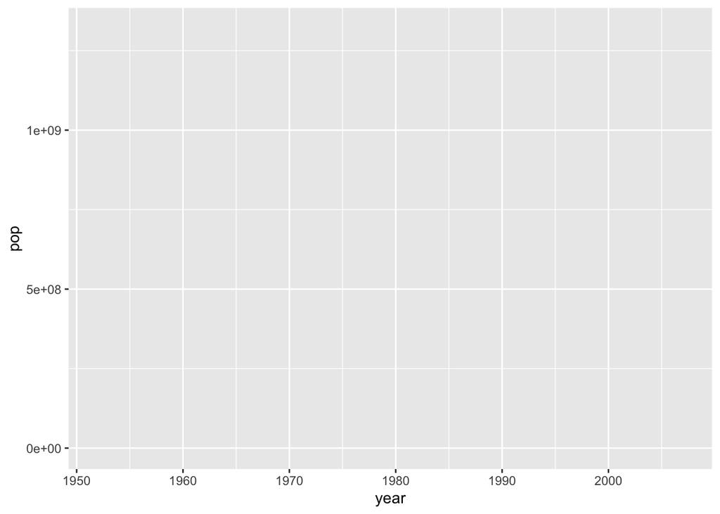

```r
g
```

We have told `ggplot()` that we will be using the gapminder data and what will be on the x and y axes. This information is stored in `g`, but we have not specified *how* we want the data to be displayed. This is the role of a $geom_$, which can be added to the object using `+`. To prooduce a scatter plot we can use `geom_point()`. There are lots of other ready made geometries, which we will get to later.

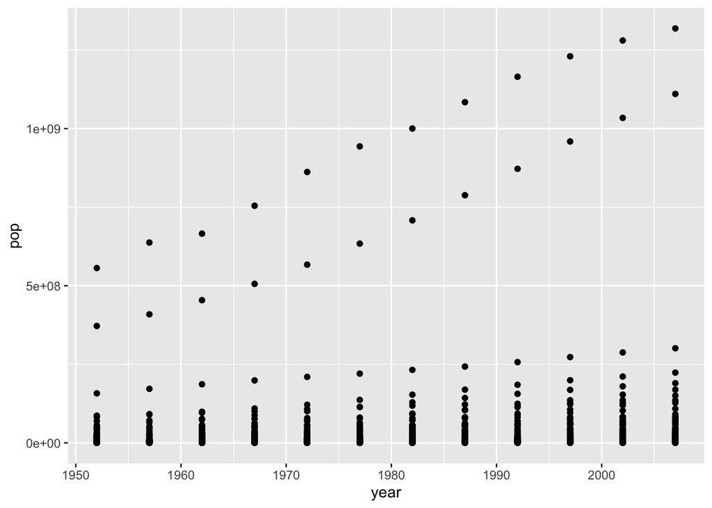

```r
g1 <- g + geom_point()
g1
```

The default theme in ggplot is `theme_gray` and I am not fond of its grey background. Until we get around to making our own theme, let’s use `theme_minimal` as the default instead.

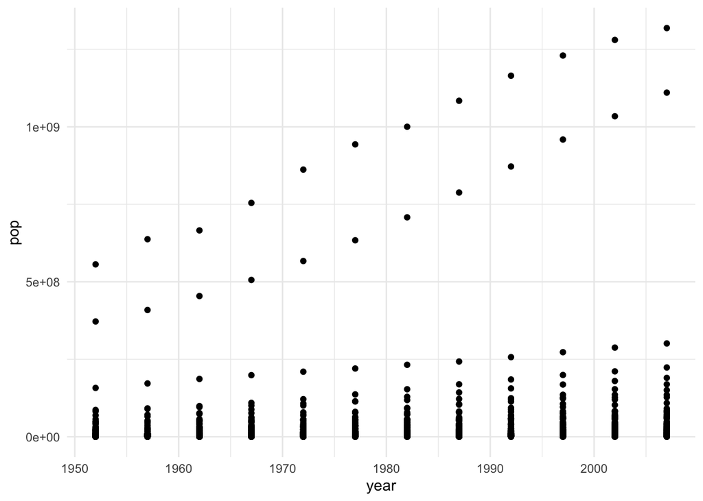

```r
theme_set(theme_minimal())
g1
```

Much better. Now that we can make a basic plot lets see how we can jazz it up a bit.

## Changing point size and colour

The colour of the plotting points and their size can be set directly within the `geom_`:

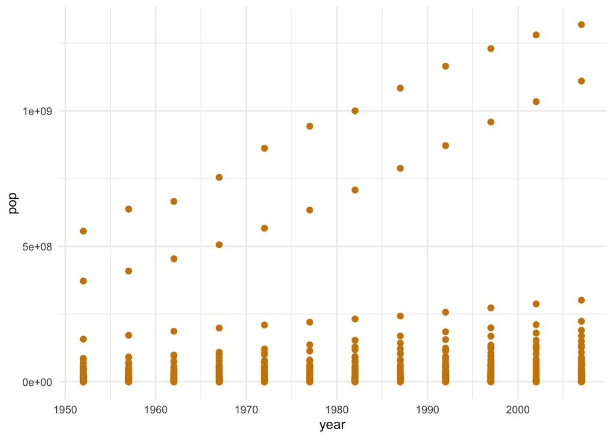

```r
g2 <- g1 + geom_point(color = 'orange3', size = 2)
g2
```

To adjust other elements, check out the relevant section below.

# All of the axis things

## Add or edit axis labels

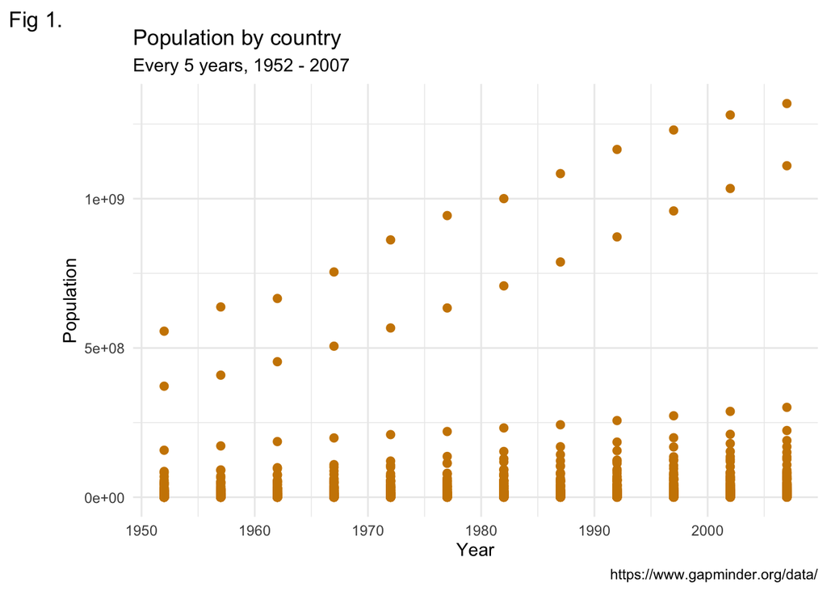

```r
g3 <- g2 +
  labs(
    x = "Year",
    y = "Population",
    title = "Population by country",
    subtitle = "Every 5 years, 1952 - 2007",
    caption = "https://www.gapminder.org/data/",
    tag = "Fig 1."
  )
g3
```

The theme controls, amongst many other things, the formatting of the labels. Components of the theme can be modified on a plot-by-plot basis.

```r
  g3 +
  theme(
    axis.title.x = element_text(
      family = "serif",
      face = 'bold.italic',
      size = 20,
      colour = 'orange3',
      hjust = 0.95),
    title =  element_text(family = 'mono'),
  )
```

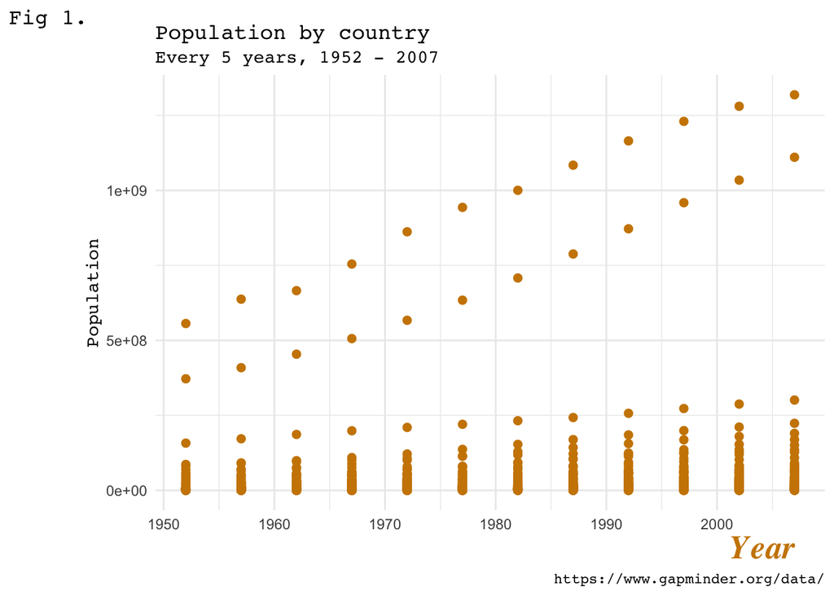

## Size and angle of tick labels

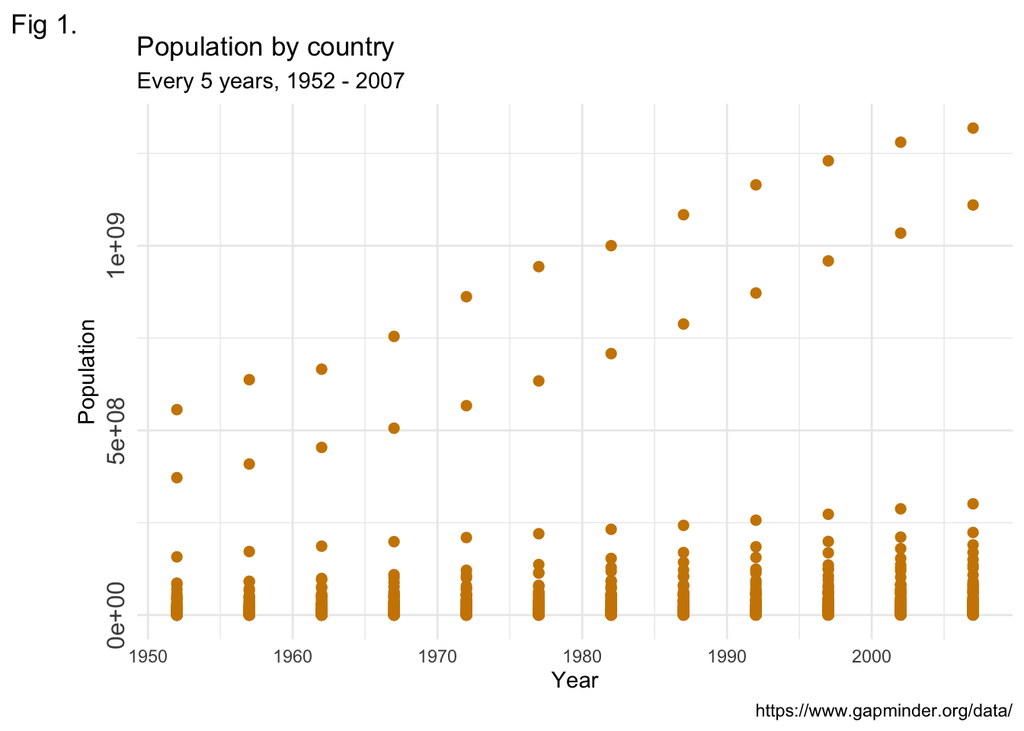

```r
g3 +
  theme(
    axis.text.y = element_text(size = 12, angle = 90, hjust = 0.5)
  )
```

## Remove ticks and text

To get rid of any element, set it to `element_blank()`.

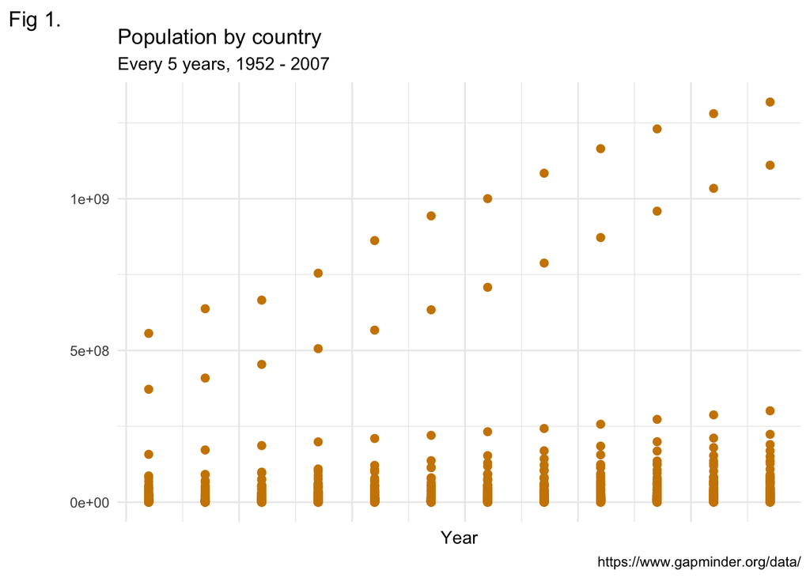

```r
g3 +
  labs(y = element_blank()) +
  theme(axis.text.x = element_blank())
```